# Aplicações do R no Melhoramento Genético Vegetal

2017-07-24

## Sobre o evento

[figure not shown]

## Tópicos

1. Gráficos básicos
   1. Representação de dados gerais
   2. Dados climáticos

## Tópicos

1. Gráficos básicos
   1. Representação de dados gerais
   2. Dados climáticos
2. Gráficos mais elaborados
   1. Dados climáticos em escala mensal
   2. Dados climáticos para experimentos com dados longitudinais

## Tópicos

1. Gráficos básicos
   1. Representação de dados gerais
   2. Dados climáticos
2. Gráficos mais elaborados
   1. Dados climáticos em escala mensal
   2. Dados climáticos para experimentos com dados longitudinais
3. Análise de experimento com modelos fixos
   1. Mapa de campo (croqui)
   2. Análises individuais e conjunta de experimentos
   3. Representação gráfica dos dados (básica e mais elaborada)

## Gráficos básicos

### Representação de dados gerais

## Gráficos Básicos

### Número de acessos no BAG

| BAG | UFV | ESALQ |
| --- | --- | --- |
| Soja | 80 | 69 |
| Trigo | 200 | 42 |
| Feijão | 183 | 125 |
| Milho | 23 | 200 |

## Gráficos Básicos

### Número de acessos no BAG

```r
# Entrada de dados
UFV<-c(80,200,183,23)
ESALQ<-c(69,42,125,200)

# Culturas
Especies<-c("Soja", "Trigo", "Feijão", "Milho")

# Múltiplas janelas
par(mfrow=c(1,2))

# Barplot
barplot(UFV, names.arg=Especies,  ylab = 'Número de acessos',
        xlab = 'Culturas', main = 'BAG UFV')
barplot(ESALQ, names.arg=Especies,  ylab = 'Número de acessos',
        xlab = 'Culturas', main = 'BAG ESALQ')
```

## Gráficos Básicos

### Número de acessos no BAG

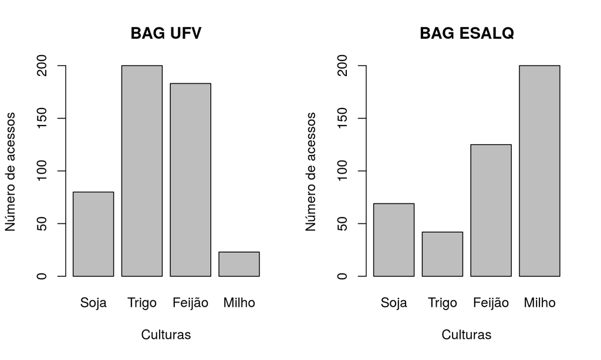

## Número de acessos no BAG

### barplot(UFV, …, density=30)

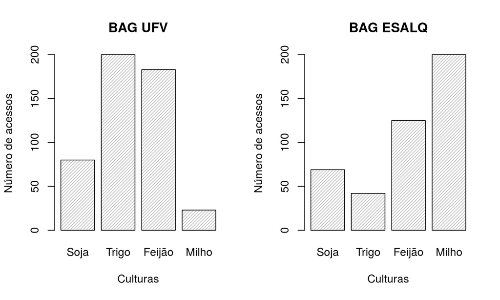

## Número de acessos no BAG

### barplot(UFV, …, density=30, angle = 90)

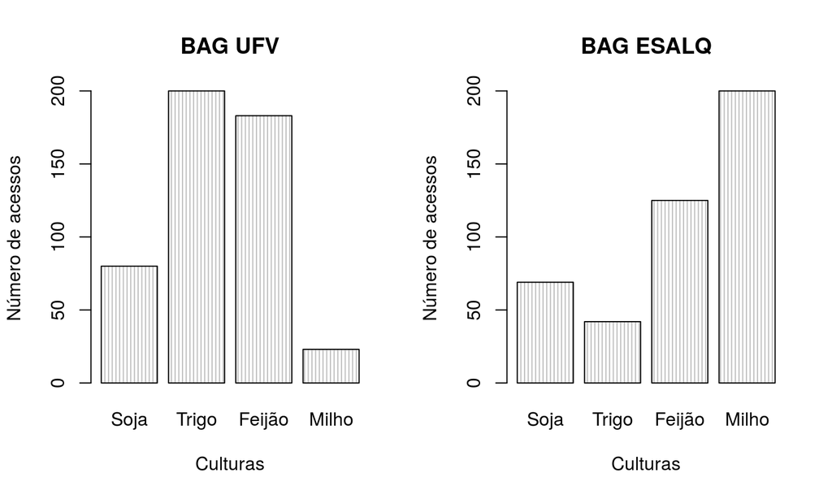

## Número de acessos no BAG

### barplot(UFV, …, density=30, angle = 200)

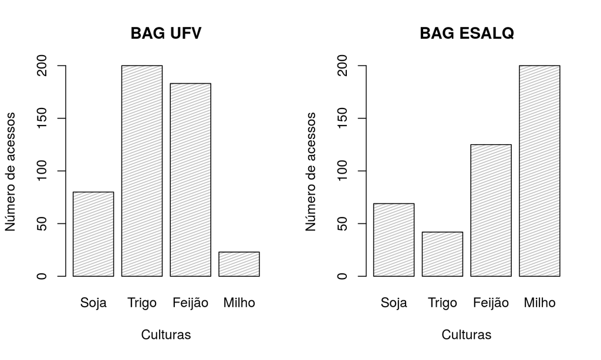

## Número de acessos no BAG

### barplot(UFV, …, density=30, angle = 200, border = NA)

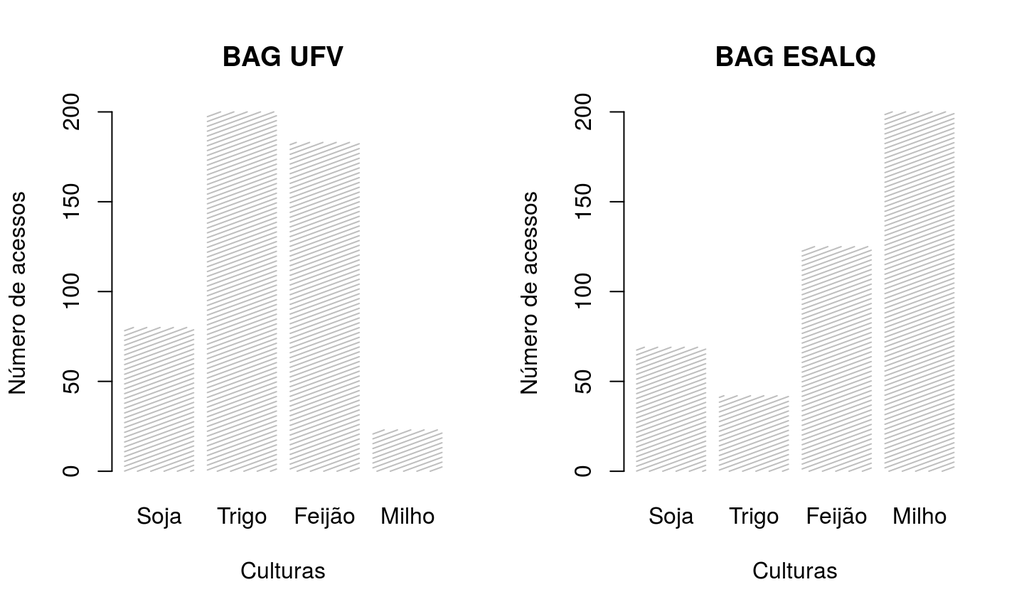

## Número de acessos no BAG

### barplot(UFV, …, col = 'green')

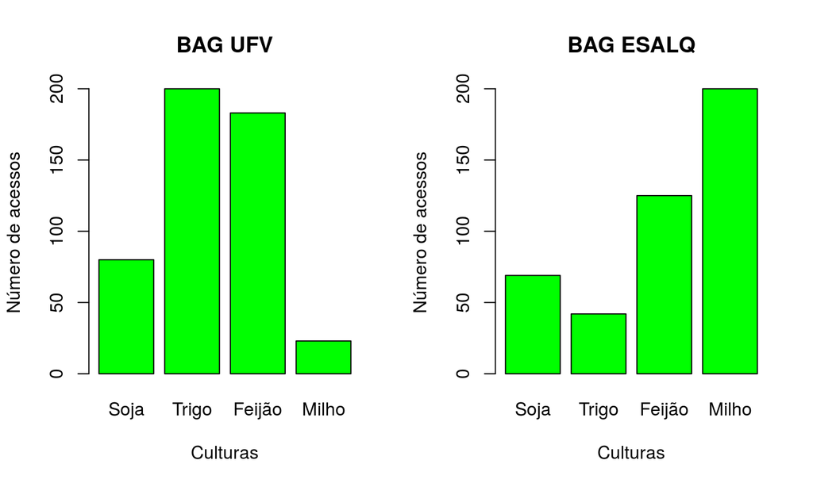

## Número de acessos no BAG

### barplot(UFV, …, col=c("red","green", "black","blue"))

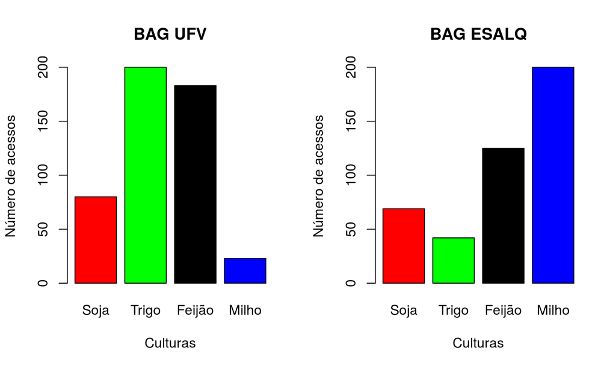

## Gráfico básicos e mais elaborados

### Dados climáticos

## Dados Climáticos dos Experimentos

### Londrina - PR

```r
Clima_Exp<-read.table("http://cristianetaniguti.github.io/Workshop_
                      genetica_esalq//praticas_2017/
                      Tempo_Londrina.csv",
                      header = T, sep = ";", dec = ",")
head(Clima_Exp)
```

```
##   dia     Mes prec.mm       Data
## 1   1 Janeiro    51.2 2017-01-01
## 2   2 Janeiro    44.8 2017-01-02
## 3   3 Janeiro     6.8 2017-01-03
## 4   4 Janeiro     0.6 2017-01-04
## 5   5 Janeiro     4.8 2017-01-05
## 6   6 Janeiro     0.0 2017-01-06
```

Fonte: [IAPAR](http://www.iapar.br/modules/conteudo/conteudo.php?conteudo=1828)

## Dados Climáticos dos Experimentos

### Londrina - PR

```r
summary(Clima_Exp)
```

```
##       dia              Mes        prec.mm              Data
##  Min.   : 1.0   Abril    :30   Min.   : 0.00   2017-01-01:  1
##  1st Qu.: 8.0   Fevereiro:28   1st Qu.: 0.00   2017-01-02:  1
##  Median :16.0   Janeiro  :31   Median : 0.00   2017-01-03:  1
##  Mean   :15.6   Junho    :30   Mean   : 5.21   2017-01-04:  1
##  3rd Qu.:23.0   Maio     :31   3rd Qu.: 3.60   2017-01-05:  1
##  Max.   :31.0   Março    :31   Max.   :59.60   2017-01-06:  1
##                                                (Other)   :175
```

## Dados Climáticos dos Experimentos

### Londrina - PR

```r
summary(Clima_Exp)
```

```
##       dia              Mes        prec.mm              Data
##  Min.   : 1.0   Abril    :30   Min.   : 0.00   2017-01-01:  1
##  1st Qu.: 8.0   Fevereiro:28   1st Qu.: 0.00   2017-01-02:  1
##  Median :16.0   Janeiro  :31   Median : 0.00   2017-01-03:  1
##  Mean   :15.6   Junho    :30   Mean   : 5.21   2017-01-04:  1
##  3rd Qu.:23.0   Maio     :31   3rd Qu.: 3.60   2017-01-05:  1
##  Max.   :31.0   Março    :31   Max.   :59.60   2017-01-06:  1
##                                                (Other)   :175
```

```r
Clima_Exp$dia<-as.factor(Clima_Exp$dia)
```

## Dados Climáticos dos Experimentos

### Londrina - PR

```r
tapply(Clima_Exp$prec.mm, Clima_Exp$Mes, mean)
```

```
##     Abril Fevereiro   Janeiro     Junho      Maio     Março
##  4.653333  3.650000  8.532258  3.573333  7.406452  3.222581
```

## Dados Climáticos dos Experimentos

### Londrina - PR

```r
tapply(Clima_Exp$prec.mm, Clima_Exp$Mes, mean)
```

```
##     Abril Fevereiro   Janeiro     Junho      Maio     Março
##  4.653333  3.650000  8.532258  3.573333  7.406452  3.222581
```

```r
print(levels(Clima_Exp$Mes))
```

```
## [1] "Abril"     "Fevereiro" "Janeiro"   "Junho"     "Maio"      "Março"
```

Reordenar os fatores para mês:

```r
Clima_Exp$Mes = factor(Clima_Exp$Mes,
                       levels(Clima_Exp$Mes)[c(3,2,6,1,5,4)])
```

## Dados Climáticos dos Experimentos

### Londrina - PR

```r
tapply(Clima_Exp$prec.mm, Clima_Exp$Mes, mean)
```

```
##   Janeiro Fevereiro     Março     Abril      Maio     Junho
##  8.532258  3.650000  3.222581  4.653333  7.406452  3.573333
```

```r
tapply(Clima_Exp$prec.mm, Clima_Exp$Mes, sum)
```

```
##   Janeiro Fevereiro     Março     Abril      Maio     Junho
##     264.5     102.2      99.9     139.6     229.6     107.2
```

## Dados Climáticos dos Experimentos

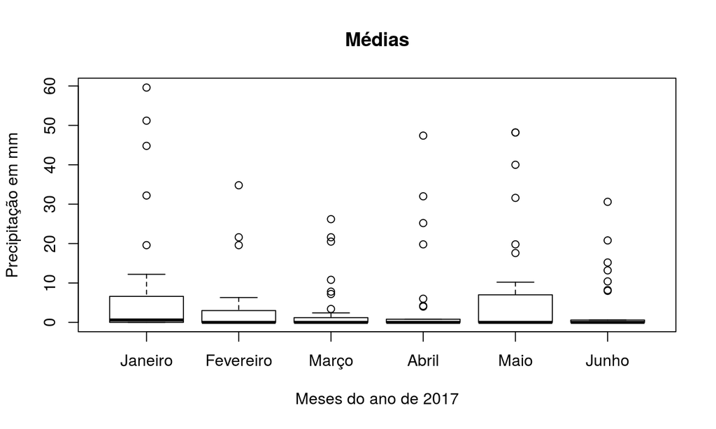

```r
plot(prec.mm~Mes, data = Clima_Exp, main="Médias",
     xlab = "Meses do ano de 2017",
     ylab = "Precipitação em mm")
```

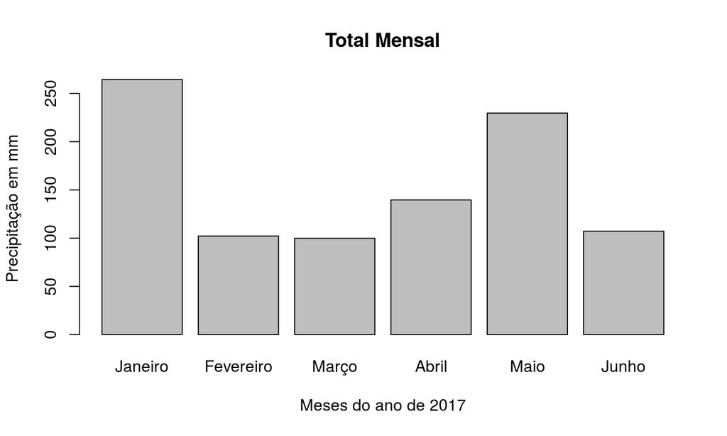

```r
barplot(tapply(Clima_Exp$prec.mm, Clima_Exp$Mes, sum),
        main="Total Mensal",
        xlab = "Meses do ano de 2017",
        ylab = "Precipitação em mm")
```

## Dados Climáticos dos Experimentos

### Londrina - PR, via *ggplot2*

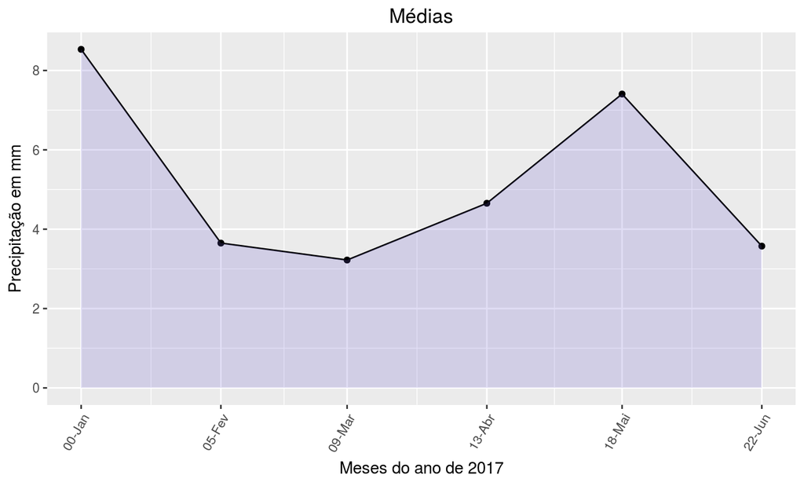

## Dados Climáticos dos Experimentos

### Londrina - PR, via *ggplot2*

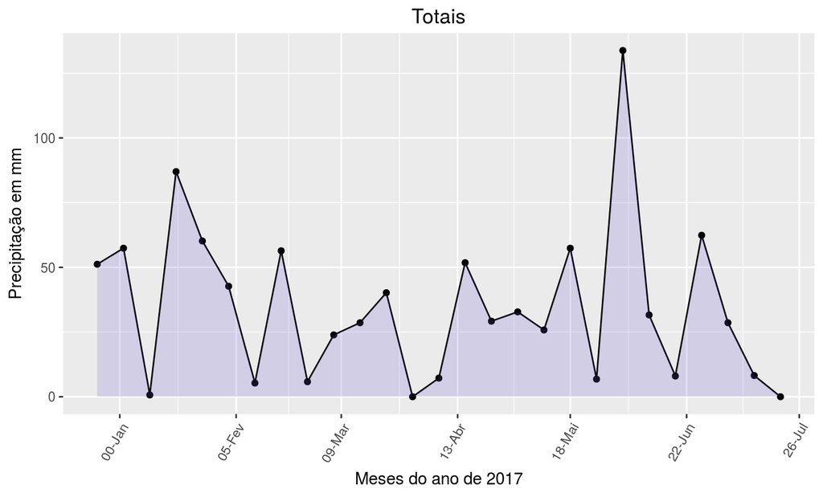

## Gráfico mais elaborado

### Dados climáticos para exp. longitudinais

## Dados Climáticos - Exp. Longitudinais

### Londrina - PR

```r
Clima_Long <- matrix(c(302.9,205.9,81.2,86,7.6,88.7,103.2,31.7,7,278.3,140.1,86.4,
                       201.6,40.3,87.8,159,64.5,344.2,33.1,1,65,111.1,120,232.7,
                       202.4,328.5,146.8,134.7,173.1,250.2,71.5,0,84.7,259.5,96.4,125.9,
                       148,172.2,146.2,162,96.7,65.7,102.8,19.5,176.3,9.9,148.4,234.7,
                       201.2,173.8,118.3,65,145.4,10.3,345.9,33.2,201.5,256.5,516.1,390.6,
                       417.8,308.4,131.9,79,292.9,108.5,33.8,120.7,56.2,187.8,87.3,152.1),
                     6,12,byrow=TRUE)
```

[output not shown]

Fonte: [IAPAR](http://www.iapar.br/modules/conteudo/conteudo.php?conteudo=1828)

## Dados Climáticos - Exp. Longitudinais

### Londrina - PR

```r
colnames(Clima_Long) <- c("Jan", "Feb", "Mar", "Apr", "May", "Jun",
                          "Jul", "Aug", "Sep", "Oct", "Nov", "Dec")

rownames(Clima_Long) <- c("2011", "2012", "2013",
                          "2014", "2015", "2016")
Clima_Long
```

```
##        Jan   Feb   Mar   Apr   May   Jun   Jul   Aug   Sep   Oct   Nov
## 2011 302.9 205.9  81.2  86.0   7.6  88.7 103.2  31.7   7.0 278.3 140.1
## 2012 201.6  40.3  87.8 159.0  64.5 344.2  33.1   1.0  65.0 111.1 120.0
## 2013 202.4 328.5 146.8 134.7 173.1 250.2  71.5   0.0  84.7 259.5  96.4
## 2014 148.0 172.2 146.2 162.0  96.7  65.7 102.8  19.5 176.3   9.9 148.4
## 2015 201.2 173.8 118.3  65.0 145.4  10.3 345.9  33.2 201.5 256.5 516.1
## 2016 417.8 308.4 131.9  79.0 292.9 108.5  33.8 120.7  56.2 187.8  87.3
##        Dec
## 2011  86.4
## 2012 232.7
## 2013 125.9
## 2014 234.7
## 2015 390.6
## 2016 152.1
```

## Dados Climáticos - Exp. Longitudinais

### Londrina - PR, via *lattice* e *hydroTSM*

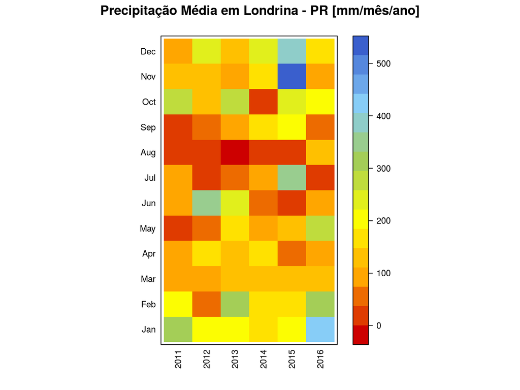

```r
library(lattice)
library(hydroTSM)
print(matrixplot(Clima_Long, ColorRamp="Precipitation",
                 main="Precipitação Média em Londrina
                 - PR [mm/mês/ano]"))
```

## Análise de experimento com mod. fixos

## Análise de experimento

### Entrada dos dados

```r
rm(list=ls())

Feijão <- read.table("http://cristianetaniguti.github.io/Workshop_
                     genetica_esalq//praticas_2017/
                     Feijao_Magno.csv", header = TRUE,
                     sep = ";", dec = ",", na.strings = TRUE)
head(Feijão)
```

```
##   Cultivar  Local Bloco Produtividade
## 1        1 Lavras     1          1000
## 2        2 Lavras     1           800
## 3        3 Lavras     1           700
## 4        4 Lavras     1           920
```

Fonte: [Ramalho et al. 2012](http://www.livroceres.com.br/produtos_descricao.asp?lang=pt_BR&codigo_produto=146)

## Análise de experimento

```r
summary(Feijão)
```

```
##     Cultivar               Local        Bloco   Produtividade
##  Min.   : 1.0   Lavras        :30   Min.   :1   Min.   : 120.0
##  1st Qu.: 3.0   Patos de Minas:30   1st Qu.:1   1st Qu.: 327.5
##  Median : 5.5                       Median :2   Median : 600.0
##  Mean   : 5.5                       Mean   :2   Mean   : 608.5
##  3rd Qu.: 8.0                       3rd Qu.:3   3rd Qu.: 832.5
##  Max.   :10.0                       Max.   :3   Max.   :1090.0
```

## Análise de experimento

```r
summary(Feijão)
```

```
##     Cultivar               Local        Bloco   Produtividade
##  Min.   : 1.0   Lavras        :30   Min.   :1   Min.   : 120.0
##  1st Qu.: 3.0   Patos de Minas:30   1st Qu.:1   1st Qu.: 327.5
##  Median : 5.5                       Median :2   Median : 600.0
##  Mean   : 5.5                       Mean   :2   Mean   : 608.5
##  3rd Qu.: 8.0                       3rd Qu.:3   3rd Qu.: 832.5
##  Max.   :10.0                       Max.   :3   Max.   :1090.0
```

```r
Feijão$Cultivar <- as.factor(Feijão$Cultivar)
Feijão$Bloco <- as.factor(Feijão$Bloco)
```

## Análise de experimento

```r
summary(Feijão)
```

```
##     Cultivar             Local    Bloco  Produtividade
##  1      : 6   Lavras        :30   1:20   Min.   : 120.0
##  2      : 6   Patos de Minas:30   2:20   1st Qu.: 327.5
##  3      : 6                       3:20   Median : 600.0
##  4      : 6                              Mean   : 608.5
##  5      : 6                              3rd Qu.: 832.5
##  6      : 6                              Max.   :1090.0
##  (Other):24
```

```r
str(Feijão)
```

```
## 'data.frame':    60 obs. of  4 variables:
##  $ Cultivar     : Factor w/ 10 levels "1","2","3","4",..: 1 2 3 4 5 6 7 8 9 10 ...
##  $ Local        : Factor w/ 2 levels "Lavras","Patos de Minas": 1 1 1 1 1 1 1 1 1 1 ...
##  $ Bloco        : Factor w/ 3 levels "1","2","3": 1 1 1 1 1 1 1 1 1 1 ...
##  $ Produtividade: int  1000 800 700 920 820 980 1020 600 620 930 ...
```

## Fases do Programa de Melhoramento

### Aonde estamos?

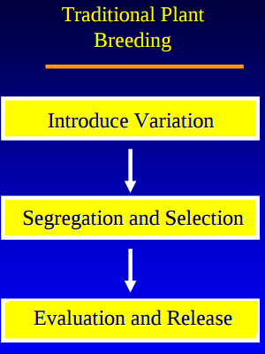

Fonte: P. Stephen et al.

## Análises individuais

## Análises individuavis

### Gerar *subsets* dos dados

```r
Feijão.Lavras<- subset(Feijão, Feijão$Local=='Lavras')
Feijão.Patos<- subset(Feijão, Feijão$Local=='Patos de Minas')
summary(Feijão.Lavras)
```

```
##     Cultivar             Local    Bloco  Produtividade
##  1      : 3   Lavras        :30   1:10   Min.   : 600.0
##  2      : 3   Patos de Minas: 0   2:10   1st Qu.: 725.0
##  3      : 3                       3:10   Median : 845.0
##  4      : 3                              Mean   : 844.3
##  5      : 3                              3rd Qu.: 970.0
##  6      : 3                              Max.   :1090.0
##  (Other):12
```

Média dos dados para Lavras:

```r
tapply(Feijão.Lavras$Produtividade, Feijão.Lavras$Local, mean)
```

```
##         Lavras Patos de Minas
##       844.3333             NA
```

Como resolver?

Média dos dados para Lavras:

```r
tapply(Feijão.Lavras$Produtividade, Feijão.Lavras$Local, mean)
```

```
##         Lavras Patos de Minas
##       844.3333             NA
```

Como resolver? (equivalente ao as.factor)

```r
Feijão.Lavras = transform(Feijão.Lavras, Cultivar = factor(Cultivar),
                          Bloco = factor(Bloco),
                          Local = factor(Local))
Feijão.Patos = transform(Feijão.Patos, Cultivar = factor(Cultivar),
                         Bloco = factor(Bloco),
                         Local = factor(Local))
tapply(Feijão.Lavras$Produtividade, Feijão.Lavras$Local, mean)
```

```
##   Lavras
## 844.3333
```

## Análises individuais - Passo a passo

Gerando o croqui (mapa de campo) dos experimentos:

1 - Definindo os tratamentos

```r
Cultivar<- c("1","2","3","4","5","6","7","8","9","10") #ou
Cultivar<-c(levels(Feijão$Cultivar)) #já temos os dados
```

2 - Definindo os número de blocos e/ou repetições

```r
Blocos<-c(3)
```

3 - Gerar o croqui (sorteio)/Mapa de campo

```r
require(agricolae)
Croqui_Lavras<-design.rcbd(Cultivar, seed = 1, Blocos, first=TRUE)$book
Croqui_Patos<-design.rcbd(Cultivar, seed = 2, Blocos, first=TRUE)$book
```

## Croqui para Lavras

```r
Croqui_Lavras
```

```
##    plots block Cultivar
## 1    101     1        4
## 2    102     1        5
## 3    103     1        8
## 4    104     1        9
## 5    105     1        7
## 6    106     1        3
## 7    107     1        2
## 8    108     1        1
## 9    109     1       10
## 10   110     1        6
## 11   201     2        4
## 12   202     2        8
## 13   203     2        3
## 14   204     2        7
```

[output cut: 16 more lines]

## Croqui para Patos de Minas

```r
Croqui_Patos
```

[output not shown]

[output cut: 16 more lines]

## Croqui/Mapa de campo

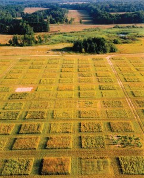

Fonte:[YaleISPS](http://isps.yale.edu/field-experiments-initiative)

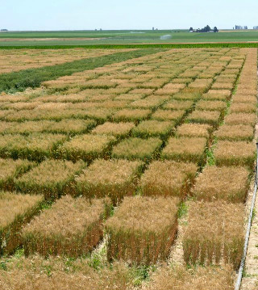

Fonte:[Ashu Guru](https://passel.unl.edu/pages/printinformationmodule.php?idinformationmodule=1130447275)

## Análises individuais - Passo a passo

Modelo estatístico para ANAVA individual:

**Produtividade = Média + Genótipo + Bloco + Erro**

## Análises individuais - Passo a passo

Modelo estatístico para ANAVA individual:

**Produtividade = Média + Genótipo + Bloco + Erro**

Formalizando…

**\(Y_{kl} = \mu + t_{k} + b_{l} + e_{kl}\)**

Sendo \(k\) = 1,2…,10 e \(l\) = 1,2,3, onde:

\(Y_{kl}\) é o valor observado para a produtividade referente ao \(k-ésimo\) genótipo no \(l-ésimo\) bloco;

\(\mu\) é a média dos genótipos para o local;

\(t_{k}\) é o efeito fixo dos genótipos \(k\) no valor observado;

\(b_{l}\) é o efeito fixo do bloco \(l\); e

\(e_{ij}\) é o erro associado a observação \(y_{ij}\)

## Quais são as nossas hipóteses?

\(H_{0}\) = \(\mu_{G1}\) = \(\mu_{G2}\) = \(\mu_{G3}\) = … = \(\mu_{G10}\), com probablidade \(\alpha\) = 0.05

\(H_{A}\) = pelo menos UMA média difere das demais, com probablidade \(\alpha\) = 0.05

## Modelo da análises individual no R

O modelo…

**Produtividade = Média + Genótipo + Bloco + Erro**

… é modelado no R da seguinte maneira:

```r
Modelo.Lavras = aov(Produtividade ~ Bloco + Cultivar, data = Feijão.Lavras)
```

## Modelo da análises individual no R

O modelo…

**\(Y_{kl} = \mu + t_{k} + b_{l} + e_{kl}\)**

… é modelado no R da seguinte maneira:

```r
Modelo.Lavras = aov(Produtividade ~ Bloco + Cultivar, data = Feijão.Lavras)
anova(Modelo.Lavras)
```

```
## Analysis of Variance Table
##
## Response: Produtividade
##           Df Sum Sq Mean Sq F value    Pr(>F)
## Bloco      2   1407     703  0.1159    0.8912
## Cultivar   9 560737   62304 10.2705 1.891e-05 ***
## Residuals 18 109193    6066
## ---
## Signif. codes:  0 '***' 0.001 '**' 0.01 '*' 0.05 '.' 0.1 ' ' 1
```

```r
Modelo.Patos = aov(Produtividade ~ Bloco + Cultivar, data = Feijão.Patos)
anova(Modelo.Patos)
```

```
## Analysis of Variance Table
##
## Response: Produtividade
##           Df Sum Sq Mean Sq F value    Pr(>F)
## Bloco      2  23407   11703  4.9074    0.0199 *
## Cultivar   9 459453   51050 21.4064 7.438e-08 ***
## Residuals 18  42927    2385
## ---
## Signif. codes:  0 '***' 0.001 '**' 0.01 '*' 0.05 '.' 0.1 ' ' 1
```

```r
Modelo.Patos = aov(Produtividade ~ Bloco + Cultivar, data = Feijão.Patos)
anova(Modelo.Patos)
```

```
## Analysis of Variance Table
##
## Response: Produtividade
##           Df Sum Sq Mean Sq F value    Pr(>F)
## Bloco      2  23407   11703  4.9074    0.0199 *
## Cultivar   9 459453   51050 21.4064 7.438e-08 ***
## Residuals 18  42927    2385
## ---
## Signif. codes:  0 '***' 0.001 '**' 0.01 '*' 0.05 '.' 0.1 ' ' 1
```

Como os 10 genótipos foram avaliados em dois locais, podemos efetuar a **análise de variância conjunta**, para diagnosticar se há **interação genótipos por ambientes**. Contudo, antes é preciso verificar a homogeneidade de variâncias das análises individuais. Essa situação é **MUITO** comum em programas de melhoramento de plantas.

## Análise conjunta

## Verificação da homogeneidade de variâncias

1 - Teste de Hartley: Razão entre a maior e a menor variância (QMres):

**H = \(\frac{max(\sigma^{2})}{min(\sigma^{2})}\)**

## Verificação da homogeneidade de variâncias

1 - Teste de Hartley: Razão entre a maior e a menor variância (QMres):

**H = \(\frac{max(\sigma^{2})}{min(\sigma^{2})}\)**

```r
6066/2385
```

```
## [1] 2.543396
```

Em geral, se H < 7, pode-se efetuar a ANAVA conjunta.

Fonte: [Pimentel Gomes 1990, pág 128](http://www.ebah.com.br/content/ABAAAfONsAE/frederico-pimentel-gomes-curso-estatistica-experimental-ed-13-esalq-1990-c-r)

## Modelo da análise conjunta

**Prod = Média + Gen + Local + Bloco(Local) + Gen x Local + Erro**

## Modelo da análise conjunta

Formalizando…

**\(Y_{klq} = \mu + t_{k} + a_{q} + b_{(l)q} + (ta)_{kq} + e_{(q)kl}\)**

Em que:

\(Y_{klq}\) é o valor de produtividade observado para o genótipo \(k\) no bloco \(l\) dentro do local \(q\);

\(\mu\) é a média geral dos genótipos;

\(t_{k}\) é o efeito fixo dos genótipos \(k\);

\(a_{q}\) é o efeito do local \(q\);

\(b_{(l)q}\) é o efeito do bloco \(l\) dentro do ambiente \(q\);

\((ta)_{kq}\) é o efeito da interação genótipos \(k\) por locais \(q\); e

\(e_{(q)kl}\) é o erro experimental médio

## Modelo da análise conjunta

O modelo…

**Prod = Média + Gen + Local + Bloco(Local) + Gen x Local + Erro**

… é modelado no R da seguinte maneira:

```r
Modelo_Conj<- aov(Produtividade~Cultivar + Local + Local:Bloco +
                    Local:Cultivar, data = Feijão)
```

## Modelo da análise conjunta

O modelo…

**\(Y_{klq} = \mu + t_{k} + a_{q} + b_{(l)q} + (ta)_{kq} + e_{(q)kl}\)**

… é modelado no R da seguinte maneira:

```r
Modelo_Conj<- aov(Produtividade~Cultivar + Local + Local:Bloco +
                    Local:Cultivar, data = Feijão)
anova(Modelo_Conj)
```

```
## Analysis of Variance Table
##
## Response: Produtividade
##                Df  Sum Sq Mean Sq  F value    Pr(>F)
## Cultivar        9  561415   62379  14.7624 1.203e-09 ***
## Local           1 3337042 3337042 789.7285 < 2.2e-16 ***
## Local:Bloco     4   24813    6203   1.4681    0.2322
## Cultivar:Local  9  458775   50975  12.0635 1.693e-08 ***
## Residuals      36  152120    4226
## ---
## Signif. codes:  0 '***' 0.001 '**' 0.01 '*' 0.05 '.' 0.1 ' ' 1
```

## Análise conjunta

### Médias dos genótipos entre locais

```r
tapply(Feijão$Produtividade, Feijão$Cultivar, mean)
```

```
##        1        2        3        4        5        6        7        8
## 768.3333 683.3333 625.0000 590.0000 546.6667 605.0000 746.6667 476.6667
##        9       10
## 465.0000 578.3333
```

Faz sentido?

## Análise conjunta

### Médias dos genótipos entre locais

```r
tapply(Feijão$Produtividade, Feijão$Cultivar, mean)
```

```
##        1        2        3        4        5        6        7        8
## 768.3333 683.3333 625.0000 590.0000 546.6667 605.0000 746.6667 476.6667
##        9       10
## 465.0000 578.3333
```

Faz sentido?

**NÃO!**

## Análise conjunta

### Médias dos genótipos para cada local

```r
Médias_Lavras=tapply(Feijão.Lavras$Produtividade, Feijão.Lavras$Cultivar, mean)
sort(Médias_Lavras, decreasing = TRUE)
```

```
##         1         6         7         4        10         2         5
## 1046.6667  966.6667  940.0000  920.0000  910.0000  846.6667  836.6667
##         3         8         9
##  733.3333  633.3333  610.0000
```

```r
Médias_Patos=tapply(Feijão.Patos$Produtividade, Feijão.Patos$Cultivar, mean)
sort(Médias_Patos, decreasing = TRUE)
```

```
##        7        2        3        1        8        9        4        5
## 553.3333 520.0000 516.6667 490.0000 320.0000 320.0000 260.0000 256.6667
##       10        6
## 246.6667 243.3333
```

**Como sempre, o melhor é fazer gráficos!**

## Análise conjunta

### Representação gráfica das médias para cada local

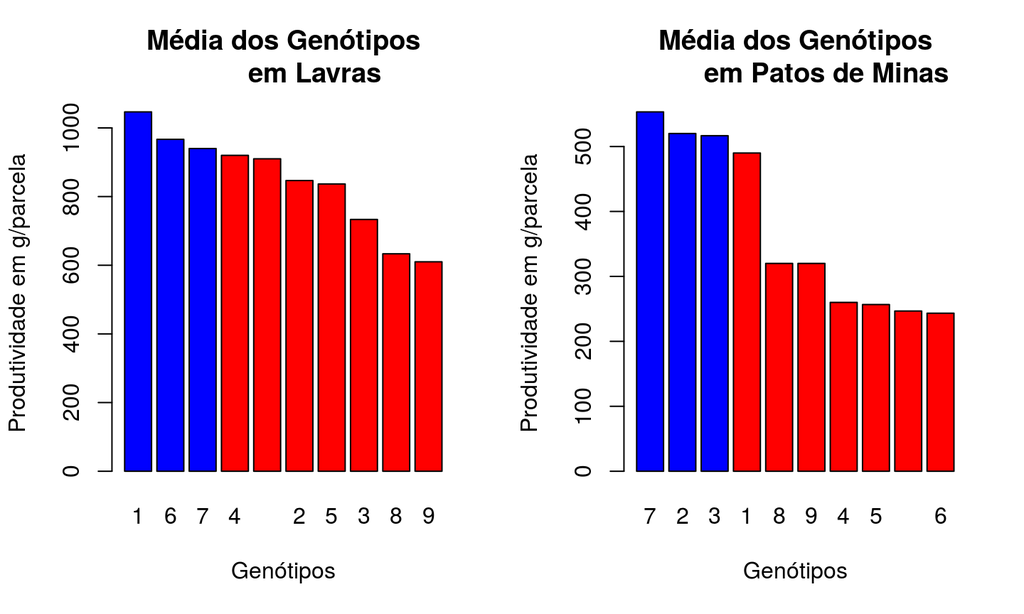

```r
par(mfrow=c(1,2))
barplot(sort(Médias_Lavras, decreasing = TRUE),
        main = "Média dos Genótipos em Lavras",
        xlab = "Genótipos",
        ylab = "Produtividade em g/parcela",
        col = c("blue","blue","blue","red","red",
                "red","red","red","red","red"))

barplot(sort(Médias_Patos, decreasing = TRUE),
        main = "Média dos Genótipos em Patos de Minas",
        xlab = "Genótipos",
        ylab = "Produtividade em g/parcela",
        col = c("blue","blue","blue","red","red",
                "red","red","red","red","red"))
```

## Via *ggplot2*, barplot

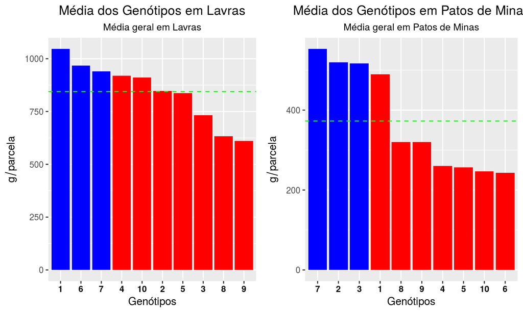

## Via *ggplot2*, barplot, default

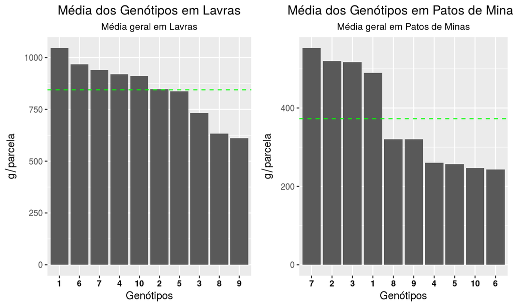

## Via *ggplot2*, boxplot

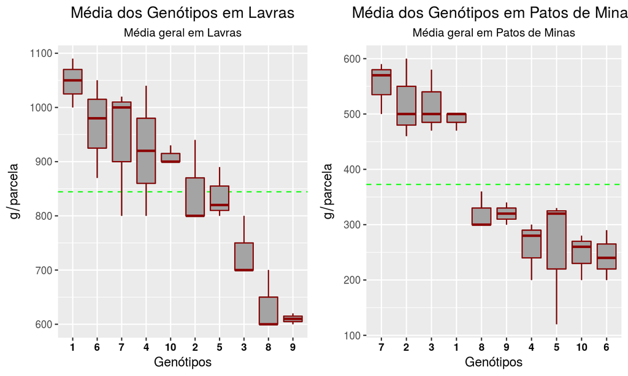

## Via *multicompView*, boxplot

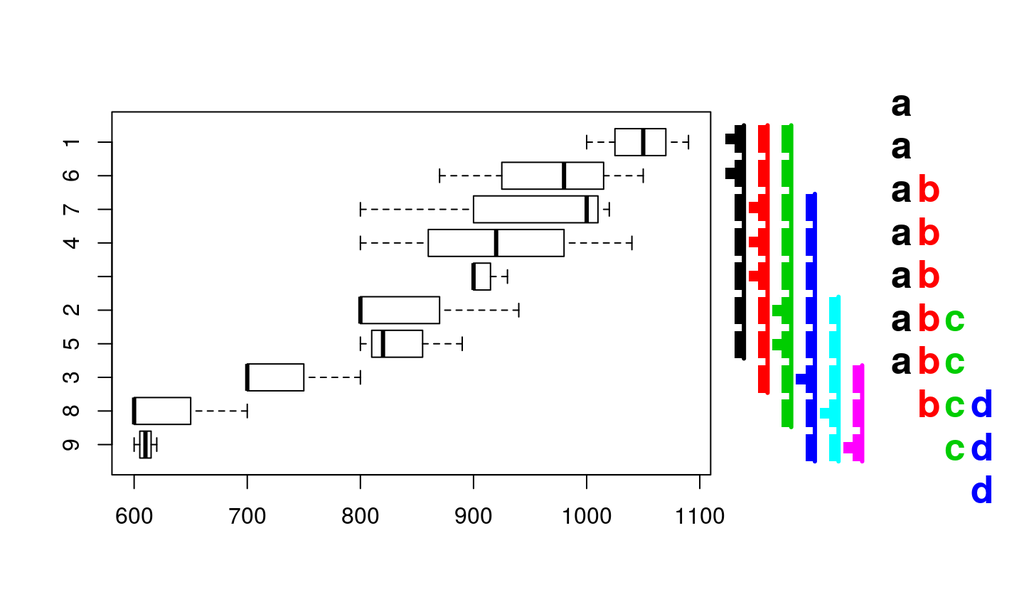

```r
library(multcompView)
par(mfrow=c(2,1))
multcompBoxplot(Produtividade ~ Cultivar, data=Feijão.Lavras,
                compFn = "TukeyHSD", decreasing = FALSE)
```

## Via *multicompView*, boxplot

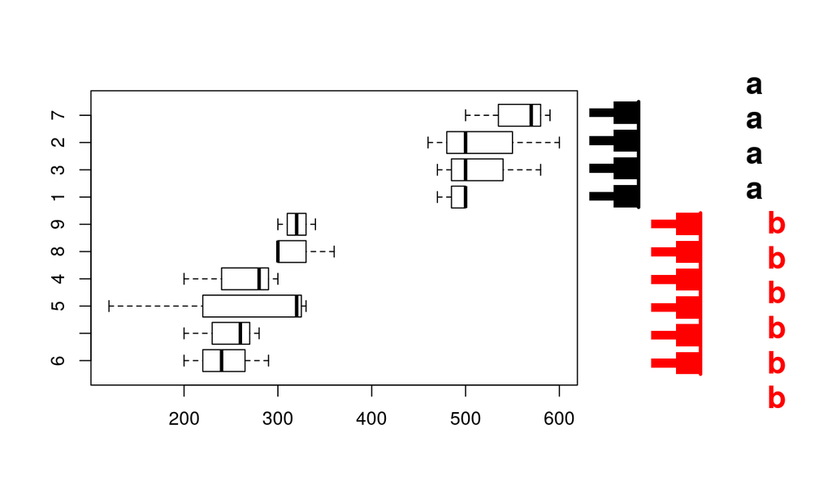

```r
library(multcompView)
multcompBoxplot(Produtividade ~ Cultivar, data=Feijão.Patos,
                compFn = "TukeyHSD", decreasing = FALSE)
```

## Representação gráfica da int. GxE

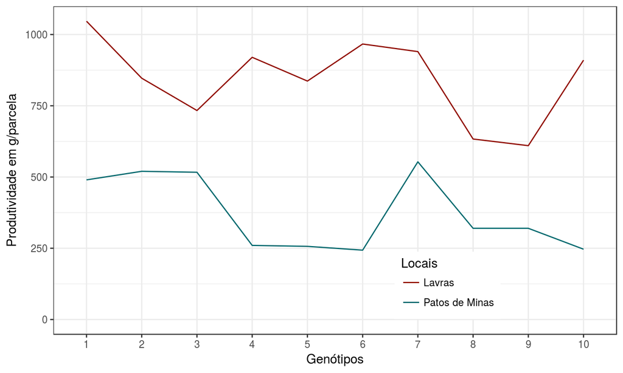

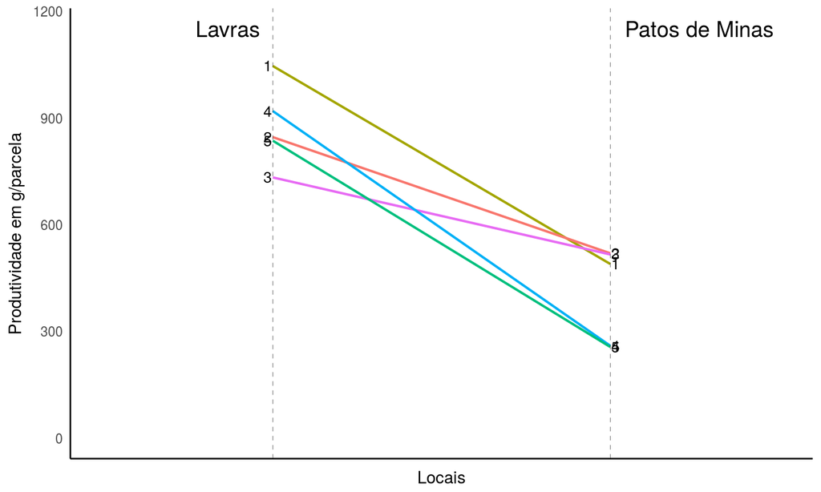

## Mapa dos locais e/ou ambientes

[interactive chart not shown]

## Gráficos, não desista!

[figure not shown]

## Gráficos, não desista!

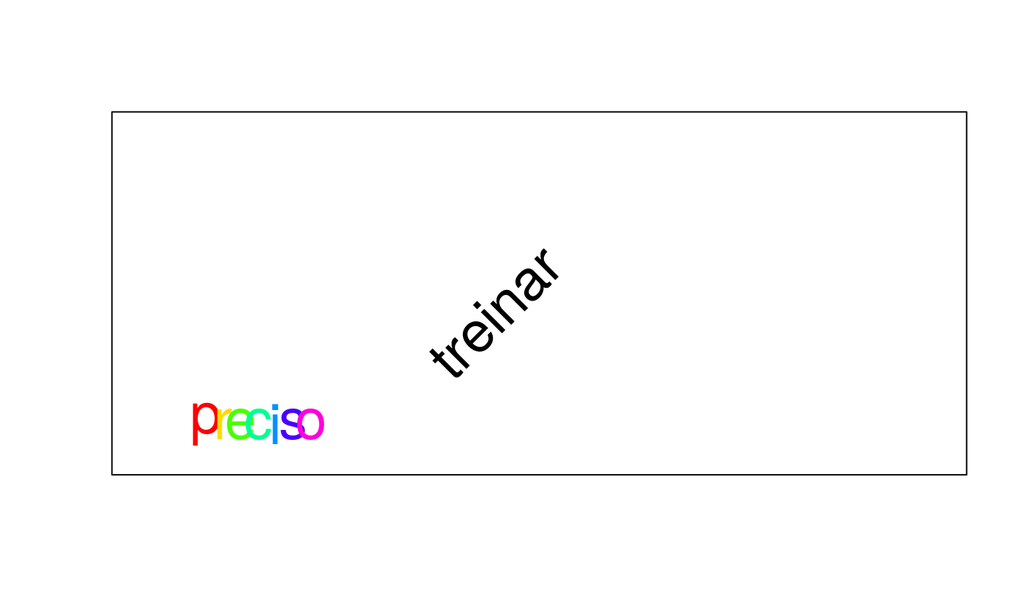

## Gráficos, não desista!

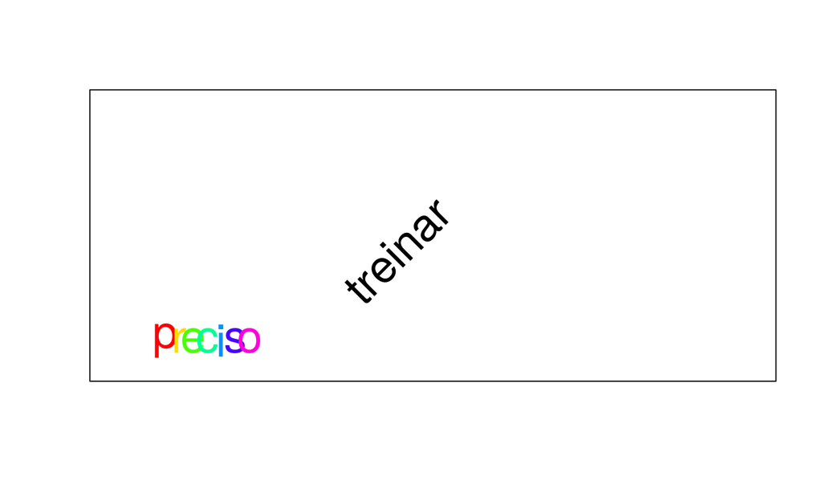

## Gráficos, não desista!

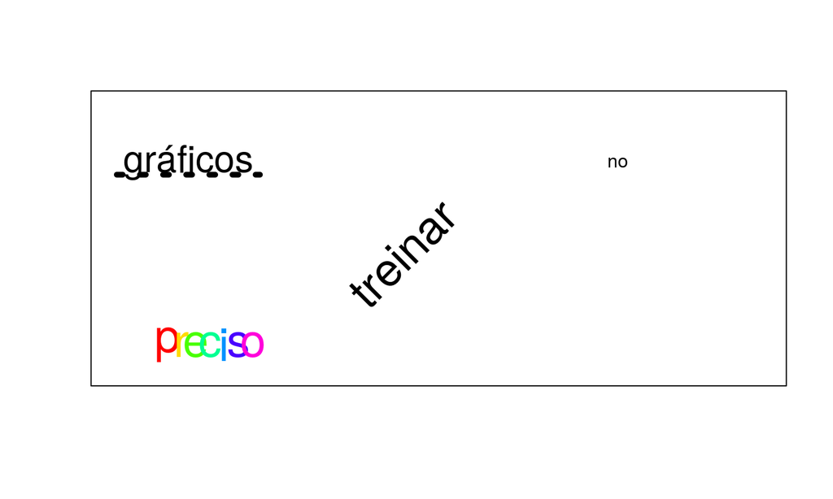

## Gráficos, não desista!

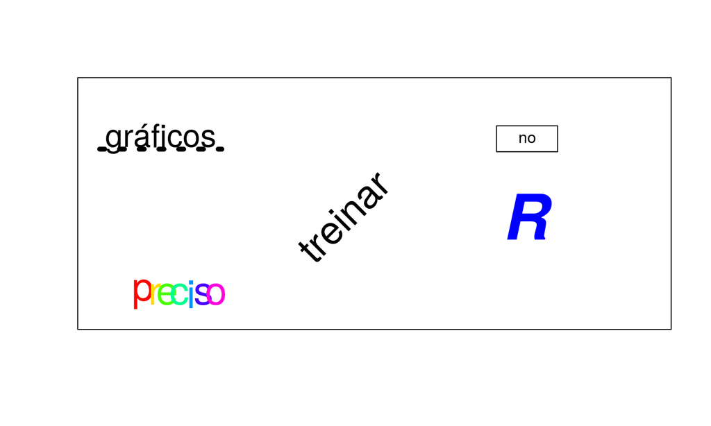

## Gráficos, não desista!

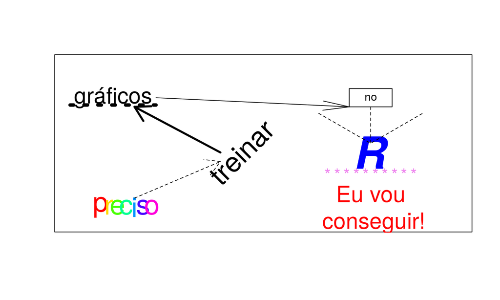

Fonte: Adilson dos Anjos (UFPR)

## Até o próximo curso!

[figure not shown]